# Coding Assignment 3

Team 06

Due: 2022-12-09 23:59

A Florida health insurance company wants to predict annual claims for individual clients. The company pulls a random sample of 50 customers. The owner wishes to charge an actuarially fair premium to ensure a normal rate of return. The owner collects all of their current customer’s health care expenses from the last year and compares them with what is known about each customer’s plan.

The data on the 50 customers in the sample is as follows:

- Charges: Total medical expenses for a particular insurance plan (in dollars)
- Age: Age of the primary beneficiary
- BMI: Primary beneficiary’s body mass index (kg/m2)
- Female: Primary beneficiary’s birth sex (0 = Male, 1 = Female)
- Children: Number of children covered by health insurance plan (includes other dependents as well)
- Smoker: Indicator if primary beneficiary is a smoker (0 = non-smoker, 1 = smoker)
- Cities: Dummy variables for each city with the default being Sanford

Answer the following questions using complete sentences and attach all output, plots, etc. within this report.

```r
insurance <- read.csv("../Data/insurance_0126_Group6.csv")

gt(head(insurance))
```

| Charges | Age | BMI | Female | Children | Smoker | WinterSprings | WinterPark | Oviedo |
| --- | --- | --- | --- | --- | --- | --- | --- | --- |
| 11848.141 | 58 | 33.100 | 1 | 0 | 0 | 0 | 0 | 1 |
| 6985.507 | 37 | 22.705 | 0 | 3 | 0 | 1 | 0 | 0 |
| 4846.920 | 27 | 32.585 | 0 | 3 | 0 | 1 | 0 | 0 |
| 2404.734 | 21 | 35.720 | 1 | 0 | 0 | 0 | 0 | 0 |
| 10600.548 | 50 | 30.970 | 0 | 3 | 0 | 0 | 0 | 0 |
| 6334.344 | 32 | 37.145 | 1 | 3 | 0 | 1 | 0 | 0 |

## Question 1

Randomly select three observations from the sample and exclude from all modeling (i.e. n=47). Provide the summary statistics (min, max, std, mean, median) of the quantitative variables for the 47 observations.

```r
set.seed(123)

index <- sample(seq_len(nrow(insurance)), size = 3)

train <- insurance[-index,]
test <- insurance[index,]
summary(train)
```

```
##     Charges           Age             BMI            Female
##  Min.   : 1149   Min.   :18.00   Min.   :17.48   Min.   :0.0000
##  1st Qu.: 3442   1st Qu.:26.00   1st Qu.:26.23   1st Qu.:0.0000
##  Median : 8060   Median :38.00   Median :30.97   Median :1.0000
##  Mean   :10241   Mean   :39.62   Mean   :30.89   Mean   :0.5745
##  3rd Qu.:11845   3rd Qu.:53.00   3rd Qu.:35.09   3rd Qu.:1.0000
##  Max.   :47897   Max.   :64.00   Max.   :46.53   Max.   :1.0000
##     Children         Smoker       WinterSprings      WinterPark
##  Min.   :0.000   Min.   :0.0000   Min.   :0.0000   Min.   :0.0000
##  1st Qu.:0.000   1st Qu.:0.0000   1st Qu.:0.0000   1st Qu.:0.0000
##  Median :1.000   Median :0.0000   Median :0.0000   Median :0.0000
##  Mean   :1.043   Mean   :0.1064   Mean   :0.2553   Mean   :0.2553
##  3rd Qu.:2.000   3rd Qu.:0.0000   3rd Qu.:0.5000   3rd Qu.:0.5000
##  Max.   :4.000   Max.   :1.0000   Max.   :1.0000   Max.   :1.0000
##      Oviedo
##  Min.   :0.0000
##  1st Qu.:0.0000
##  Median :0.0000
##  Mean   :0.2128
##  3rd Qu.:0.0000
##  Max.   :1.0000
```

```r
train %>%
  tbl_summary(statistic = list(all_continuous() ~ c("{mean} ({sd})",
                                      "{median} ({p25}, {p75})",
                                      "{min}, {max}"),
                all_categorical() ~ "{n} / {N} ({p}%)"),
type = all_continuous() ~ "continuous2")
```

| **Characteristic** | **N = 47**<sup>1</sup> |
| --- | --- |
| Charges |  |
| Mean (SD) | 10,241 (10,832) |
| Median (IQR) | 8,060 (3,442, 11,845) |
| Range | 1,149, 47,897 |
| Age |  |
| Mean (SD) | 40 (15) |
| Median (IQR) | 38 (26, 53) |
| Range | 18, 64 |
| BMI |  |
| Mean (SD) | 30.9 (6.3) |
| Median (IQR) | 31.0 (26.2, 35.1) |
| Range | 17.5, 46.5 |
| Female | 27 / 47 (57%) |
| Children |  |
| 0 | 23 / 47 (49%) |
| 1 | 10 / 47 (21%) |
| 2 | 4 / 47 (8.5%) |
| 3 | 9 / 47 (19%) |
| 4 | 1 / 47 (2.1%) |
| Smoker | 5 / 47 (11%) |
| WinterSprings | 12 / 47 (26%) |
| WinterPark | 12 / 47 (26%) |
| Oviedo | 10 / 47 (21%) |

<sup>1</sup> n / N (%)

According to the summary statictic output, the dependent variable,Charges is skewed to the right since it mean is higher than the median by about 2 thousand dollars. Since the standard deviation is high, some outliers could exist in the data.

## Question 2

Provide the correlation between all quantitative variables

```r
cor(insurance)
```

```
##                   Charges         Age         BMI      Female    Children
## Charges        1.00000000  0.63156188  0.11984359  0.12478792 -0.12251184
## Age            0.63156188  1.00000000  0.09410864  0.25563075  0.03021326
## BMI            0.11984359  0.09410864  1.00000000 -0.03888301  0.12632864
## Female         0.12478792  0.25563075 -0.03888301  1.00000000  0.03355780
## Children      -0.12251184  0.03021326  0.12632864  0.03355780  1.00000000
## Smoker         0.82667950  0.28018237 -0.02194003  0.09412416 -0.28427400
## WinterSprings  0.18155886 -0.02163867  0.05569997 -0.01911798  0.23096064
## WinterPark    -0.01385958 -0.05225310  0.22359816 -0.07445808 -0.07495949
## Oviedo        -0.09338461 -0.08435673 -0.05672896  0.03942083  0.00000000
##                    Smoker WinterSprings  WinterPark      Oviedo
## Charges        0.82667950    0.18155886 -0.01385958 -0.09338461
## Age            0.28018237   -0.02163867 -0.05225310 -0.08435673
## BMI           -0.02194003    0.05569997  0.22359816 -0.05672896
## Female         0.09412416   -0.01911798 -0.07445808  0.03942083
## Children      -0.28427400    0.23096064 -0.07495949  0.00000000
## Smoker         1.00000000    0.04318713  0.02365303  0.06400530
## WinterSprings  0.04318713    1.00000000 -0.33309617 -0.29844401
## WinterPark     0.02365303   -0.33309617  1.00000000 -0.31480009
## Oviedo         0.06400530   -0.29844401 -0.31480009  1.00000000
```

According to the correlation output,“Age” and “Smoker” variables are strongly and directly related to the dependent variable,Charges.

## Question 3

Run a regression that includes all independent variables in the data table. Does the model above violate any of the Gauss-Markov assumptions? If so, what are they and what is the solution for correcting?

```r
original_model <- lm(Charges ~., data = train[,c(1:9)] ) #pulling only original data column before data transformation

summary(original_model)
```

```
##
## Call:
## lm(formula = Charges ~ ., data = train[, c(1:9)])
##
## Residuals:
##     Min      1Q  Median      3Q     Max
## -9468.8 -1130.9   -95.9  1084.4 10860.4
##
## Coefficients:
##               Estimate Std. Error t value Pr(>|t|)
## (Intercept)   -8148.07    3083.95  -2.642   0.0119 *
## Age             293.40      41.59   7.055 2.08e-08 ***
## BMI             138.52      91.89   1.507   0.1400
## Female         -681.82    1154.14  -0.591   0.5582
## Children        317.54     478.69   0.663   0.5111
## Smoker        24978.91    2037.60  12.259 8.91e-15 ***
## WinterSprings  2289.36    1622.62   1.411   0.1664
## WinterPark    -1069.77    1604.70  -0.667   0.5090
## Oviedo        -1980.10    1608.94  -1.231   0.2260
## ---
## Signif. codes:  0 '***' 0.001 '**' 0.01 '*' 0.05 '.' 0.1 ' ' 1
##
## Residual standard error: 3719 on 38 degrees of freedom
## Multiple R-squared:  0.9026, Adjusted R-squared:  0.8821
## F-statistic: 44.04 on 8 and 38 DF,  p-value: < 2.2e-16
```

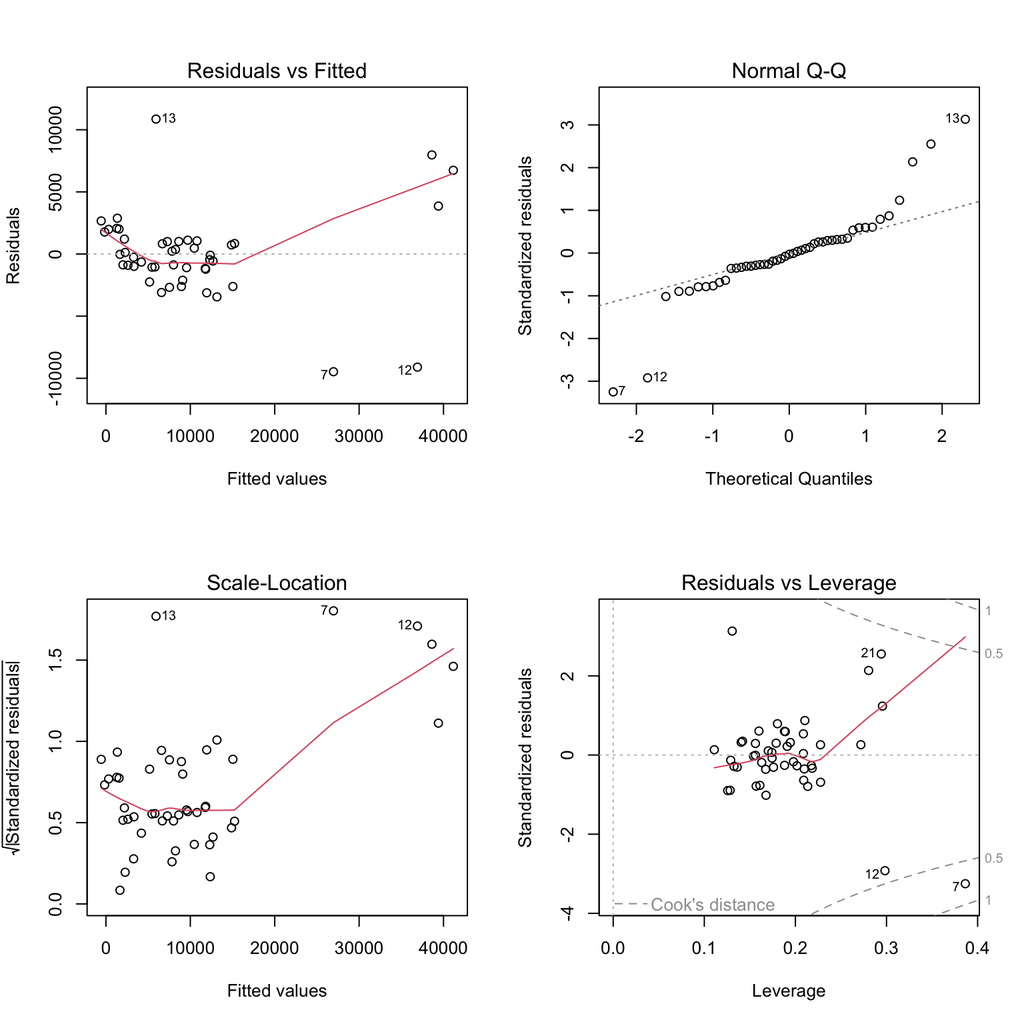

```r
par(mfrow=c(2,2))
plot(original_model)
```

```r
vif(original_model)
```

```
##           Age           BMI        Female      Children        Smoker
##      1.301281      1.114801      1.106755      1.191726      1.341536
## WinterSprings    WinterPark        Oviedo
##      1.701470      1.664110      1.473749
```

## Question 3 Answers=>

No significant VIFs are found for independent variables and no concerning multicolllinearity is detected.

The “Residual vs Fitted” model tests for the third Gauss-Markov assumption. The model shows that our results are non-linear as the data curves down and then shoots up. If it were properly specified, it would be a perfectly horizontal line with a bit of noise of around it. This is a violation of the third assumption. The solution would be to consider using ratios or percentages rather than raw data.

The “Normal Q-Q” model” checks the sixth Gauss-Markov assumption, which is that we have a normally distributed error term. In this case, there is a violation of the sixth assumption because there are large variables going far outside of our line (top right corner). To correct this violation we can fit the models to several sets of transformed data and then check to see which transformation appears to produce the most normally distributed residuals.

The “Scale-Location” model tests for heteroscedasticity. Our results show that there is a violation of the fourth Gauss-Markov assumption as the data is not in a horizontal line with corresponding noise; rather as the size gets larger, our data is spread is widening creating a “fanning out” effect. To correct this violation, we should look for subgroups in data and analyze separately. We should also use summary data (like the mean value) rather than the raw data.

The “Residuals vs Leverage” model checks for outliers. There are no Gauss-Markov violations shown.

## Question 4

Implement the solutions from question 3, such as data transformation, along with any other changes you wish. Use the sample data and run a new regression. How have the fit measures changed? How have the signs and significance of the coefficients changed?

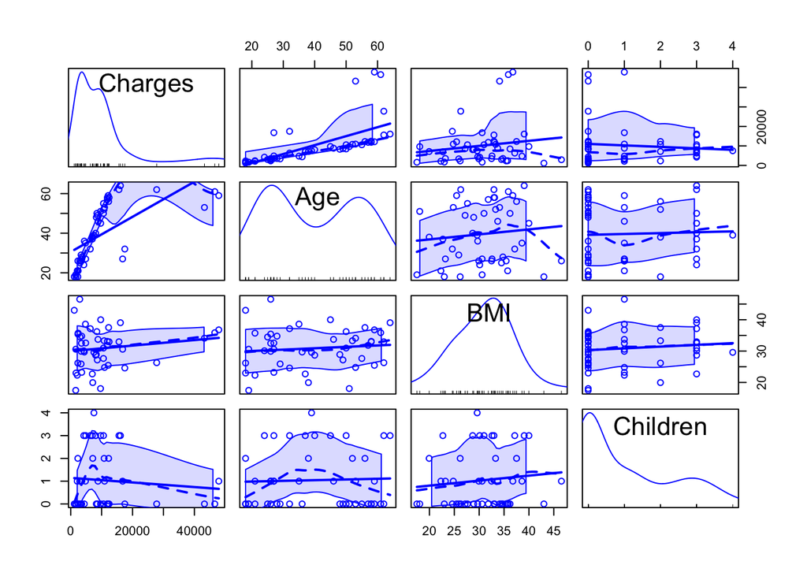

```r
#to detect non-linear realtionships and non-normally distributed variables
scatterplotMatrix(train[,c(1,2,3,5)])
```

Some nonlinearity between Charges and Age have been found.

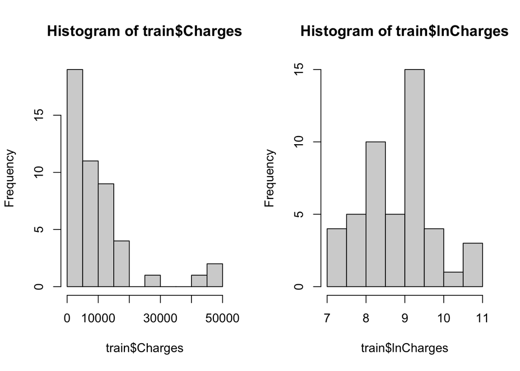

```r
#Data Transformation
#taking natural logirthm of Charges to bring possible outliers closer

par(mfrow=c(1,2))

hist(train$Charges) #before

train$lnCharges <- log(train$Charges)

hist(train$lnCharges) #after
```

Question#4 Answer==> Taking natural logirthm of Charges transfrom the dependent variable to be more normally distributed.

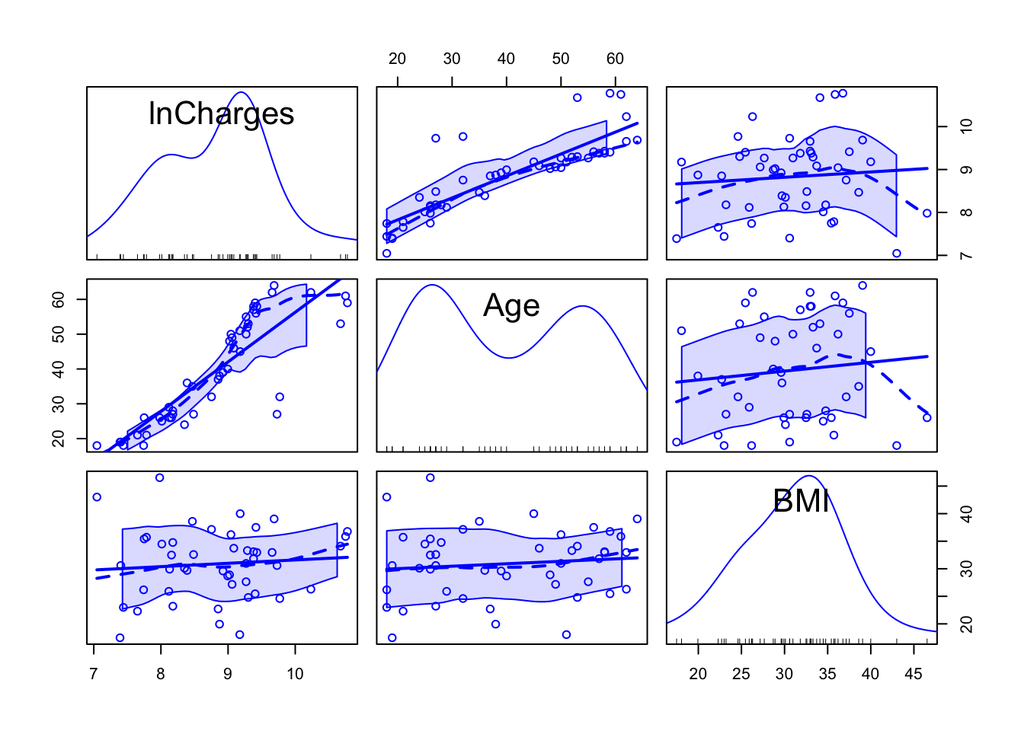

```r
#Plotting the relationships After Transformation
scatterplotMatrix(train[,c(10,2,3)]) # grabbing lnCharges
```

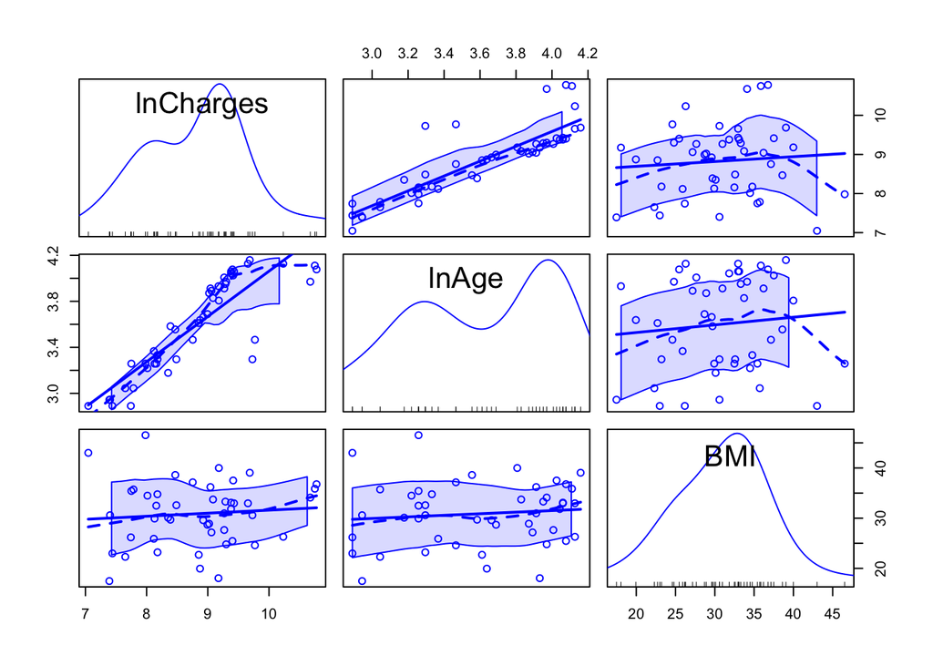

```r
#to determine if the relationship between Charges and Age is logarithmic or quadratic.

train$lnAge <- log(train$Age)
train$AgeSquared <- train$Age^2
scatterplotMatrix(train[,c(10,11,3)]) # lnChares & lnAge
```

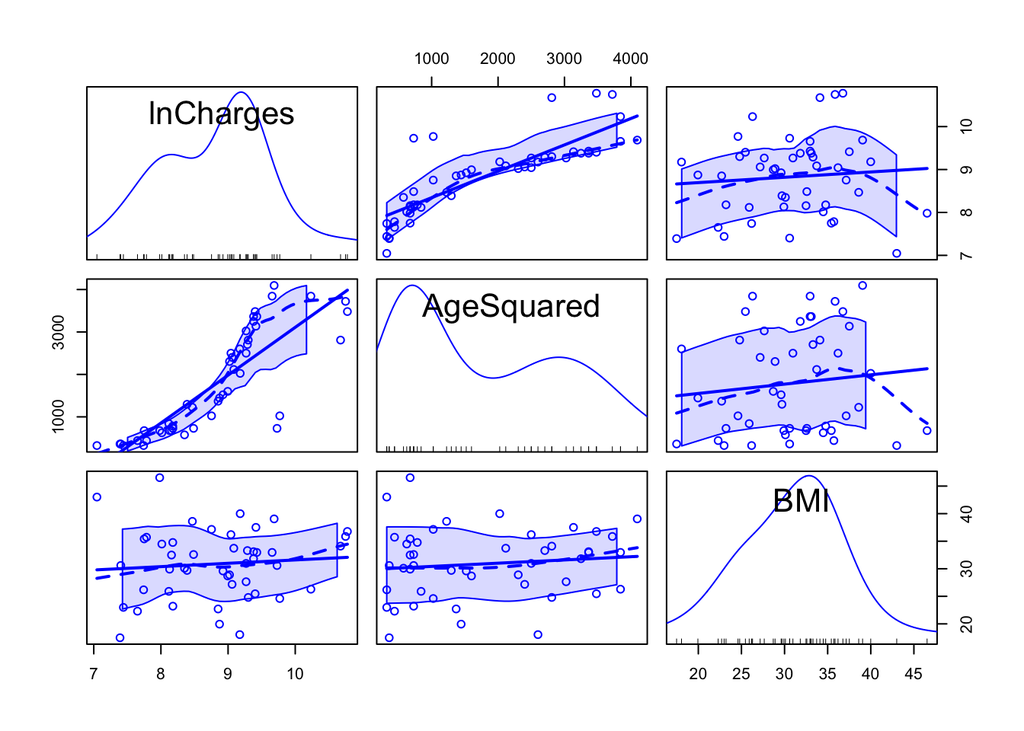

```r
scatterplotMatrix(train[,c(10,12,3)]) # lnChares & AgeSquared
```

```r
# New Regression
# Models to look at the regression coefficients.

# Model 1lnAge: Age with a logaritmic shape

model_1lnAge <- lm(lnCharges ~., data = train[,c(10,11,3:9)] )

summary(model_1lnAge)
```

```
##
## Call:
## lm(formula = lnCharges ~ ., data = train[, c(10, 11, 3:9)])
##
## Residuals:
##      Min       1Q   Median       3Q      Max
## -0.38585 -0.12001 -0.00025  0.04639  1.27010
##
## Coefficients:
##                Estimate Std. Error t value Pr(>|t|)
## (Intercept)    2.980685   0.385580   7.730 2.58e-09 ***
## lnAge          1.541723   0.103166  14.944  < 2e-16 ***
## BMI           -0.000688   0.006219  -0.111   0.9125
## Female         0.135518   0.078717   1.722   0.0933 .
## Children       0.080173   0.032527   2.465   0.0183 *
## Smoker         1.254884   0.136858   9.169 3.59e-11 ***
## WinterSprings  0.202225   0.109201   1.852   0.0718 .
## WinterPark    -0.096943   0.108649  -0.892   0.3779
## Oviedo        -0.014314   0.108391  -0.132   0.8956
## ---
## Signif. codes:  0 '***' 0.001 '**' 0.01 '*' 0.05 '.' 0.1 ' ' 1
##
## Residual standard error: 0.2518 on 38 degrees of freedom
## Multiple R-squared:  0.9354, Adjusted R-squared:  0.9218
## F-statistic: 68.76 on 8 and 38 DF,  p-value: < 2.2e-16
```

```r
# or

tbl_regression(model_1lnAge,
               estimate_fun =  ~style_sigfig(.x, digits = 4)) %>% as_gt() %>%
  gt::tab_source_note(gt::md(paste0("Adjusted R-Squared: ",round(summary(model_1lnAge)$adj.r.squared* 100,digits = 2),"%")))
```

| **Characteristic** | **Beta** | **95% CI**<sup>1</sup> | **p-value** |
| --- | --- | --- | --- |
| lnAge | 1.542 | 1.333, 1.751 | <0.001 |
| BMI | -0.0007 | -0.0133, 0.0119 | >0.9 |
| Female | 0.1355 | -0.0238, 0.2949 | 0.093 |
| Children | 0.0802 | 0.0143, 0.1460 | 0.018 |
| Smoker | 1.255 | 0.978, 1.532 | <0.001 |
| WinterSprings | 0.2022 | -0.0188, 0.4233 | 0.072 |
| WinterPark | -0.0969 | -0.3169, 0.1230 | 0.4 |
| Oviedo | -0.0143 | -0.2337, 0.2051 | 0.9 |

Adjusted R-Squared: 92.18%  
<sup>1</sup> CI = Confidence Interval

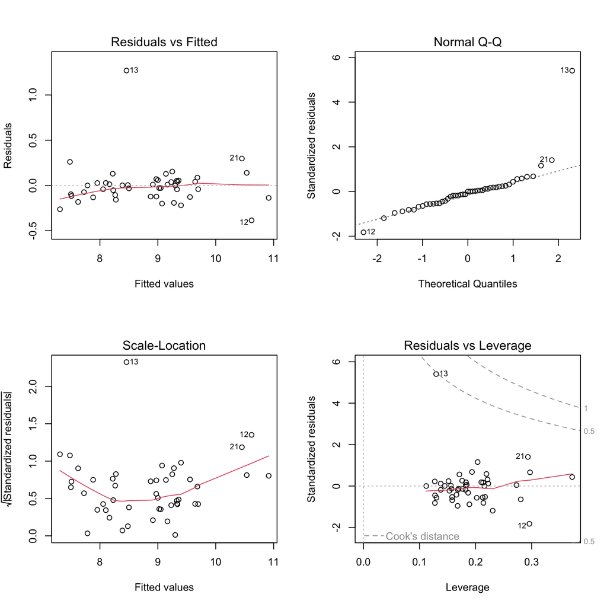

```r
par(mfrow=c(2,2))
plot(model_1lnAge)
```

```r
# Model 2AgeSq:Quadratic Relationship between Age and Charges

model_2AgeSq <- lm(lnCharges ~., data = train[,c(10,3:9,12)] )

summary(model_2AgeSq)
```

```
##
## Call:
## lm(formula = lnCharges ~ ., data = train[, c(10, 3:9, 12)])
##
## Residuals:
##      Min       1Q   Median       3Q      Max
## -0.54586 -0.13583  0.01408  0.14348  1.24806
##
## Coefficients:
##                 Estimate Std. Error t value Pr(>|t|)
## (Intercept)    7.5596702  0.2443221  30.941  < 2e-16 ***
## BMI           -0.0012183  0.0077385  -0.157   0.8757
## Female         0.1989881  0.0966186   2.060   0.0463 *
## Children       0.1027793  0.0401811   2.558   0.0146 *
## Smoker         1.2074779  0.1727264   6.991 2.53e-08 ***
## WinterSprings  0.2941239  0.1373456   2.141   0.0387 *
## WinterPark    -0.1163559  0.1348752  -0.863   0.3937
## Oviedo         0.1048258  0.1361433   0.770   0.4461
## AgeSquared     0.0004974  0.0000434  11.460 6.78e-14 ***
## ---
## Signif. codes:  0 '***' 0.001 '**' 0.01 '*' 0.05 '.' 0.1 ' ' 1
##
## Residual standard error: 0.3128 on 38 degrees of freedom
## Multiple R-squared:  0.9003, Adjusted R-squared:  0.8793
## F-statistic: 42.88 on 8 and 38 DF,  p-value: < 2.2e-16
```

```r
# or

tbl_regression(model_2AgeSq,
               estimate_fun =  ~style_sigfig(.x, digits = 4)) %>% as_gt() %>%
  gt::tab_source_note(gt::md(paste0("Adjusted R-Squared: ",round(summary(model_2AgeSq)$adj.r.squared* 100,digits = 2),"%")))
```

| **Characteristic** | **Beta** | **95% CI**<sup>1</sup> | **p-value** |
| --- | --- | --- | --- |
| BMI | -0.0012 | -0.0169, 0.0144 | 0.9 |
| Female | 0.1990 | 0.0034, 0.3946 | 0.046 |
| Children | 0.1028 | 0.0214, 0.1841 | 0.015 |
| Smoker | 1.207 | 0.8578, 1.557 | <0.001 |
| WinterSprings | 0.2941 | 0.0161, 0.5722 | 0.039 |
| WinterPark | -0.1164 | -0.3894, 0.1567 | 0.4 |
| Oviedo | 0.1048 | -0.1708, 0.3804 | 0.4 |
| AgeSquared | 0.0005 | 0.0004, 0.0006 | <0.001 |

Adjusted R-Squared: 87.93%  
<sup>1</sup> CI = Confidence Interval

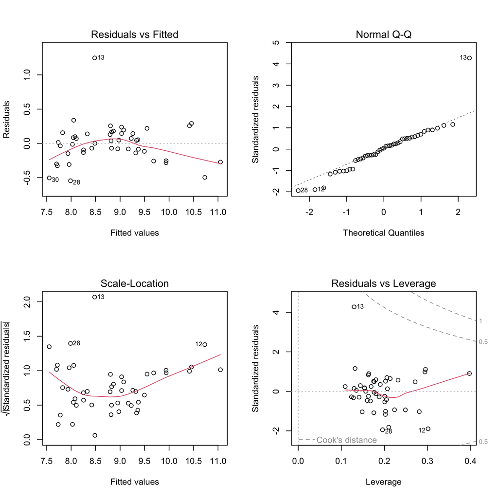

```r
par(mfrow=c(2,2))
plot(model_2AgeSq)
```

```r
# # Model 3lnBMI: BMI with a logaritmic shape
train$lnBMI <- log(train$BMI)

model_3lnBMI <- lm(lnCharges ~., data = train[,c(10,11,4:9,13)] )

summary(model_3lnBMI)
```

```
##
## Call:
## lm(formula = lnCharges ~ ., data = train[, c(10, 11, 4:9, 13)])
##
## Residuals:
##      Min       1Q   Median       3Q      Max
## -0.37769 -0.10989 -0.01101  0.04304  1.26948
##
## Coefficients:
##               Estimate Std. Error t value Pr(>|t|)
## (Intercept)    2.92002    0.65974   4.426 7.83e-05 ***
## lnAge          1.53895    0.10345  14.876  < 2e-16 ***
## Female         0.13607    0.07869   1.729   0.0919 .
## Children       0.07963    0.03255   2.447   0.0191 *
## Smoker         1.25585    0.13683   9.178 3.50e-11 ***
## WinterSprings  0.19922    0.10918   1.825   0.0759 .
## WinterPark    -0.10265    0.10830  -0.948   0.3492
## Oviedo        -0.01630    0.10855  -0.150   0.8814
## lnBMI          0.01531    0.18218   0.084   0.9335
## ---
## Signif. codes:  0 '***' 0.001 '**' 0.01 '*' 0.05 '.' 0.1 ' ' 1
##
## Residual standard error: 0.2518 on 38 degrees of freedom
## Multiple R-squared:  0.9354, Adjusted R-squared:  0.9218
## F-statistic: 68.75 on 8 and 38 DF,  p-value: < 2.2e-16
```

```r
# or

tbl_regression(model_3lnBMI,
               estimate_fun =  ~style_sigfig(.x, digits = 4)) %>% as_gt() %>%
  gt::tab_source_note(gt::md(paste0("Adjusted R-Squared: ",round(summary(model_3lnBMI)$adj.r.squared* 100,digits = 2),"%")))
```

| **Characteristic** | **Beta** | **95% CI**<sup>1</sup> | **p-value** |
| --- | --- | --- | --- |
| lnAge | 1.539 | 1.330, 1.748 | <0.001 |
| Female | 0.1361 | -0.0232, 0.2954 | 0.092 |
| Children | 0.0796 | 0.0137, 0.1455 | 0.019 |
| Smoker | 1.256 | 0.979, 1.533 | <0.001 |
| WinterSprings | 0.1992 | -0.0218, 0.4203 | 0.076 |
| WinterPark | -0.1027 | -0.3219, 0.1166 | 0.3 |
| Oviedo | -0.0163 | -0.2360, 0.2035 | 0.9 |
| lnBMI | 0.0153 | -0.3535, 0.3841 | >0.9 |

Adjusted R-Squared: 92.18%  
<sup>1</sup> CI = Confidence Interval

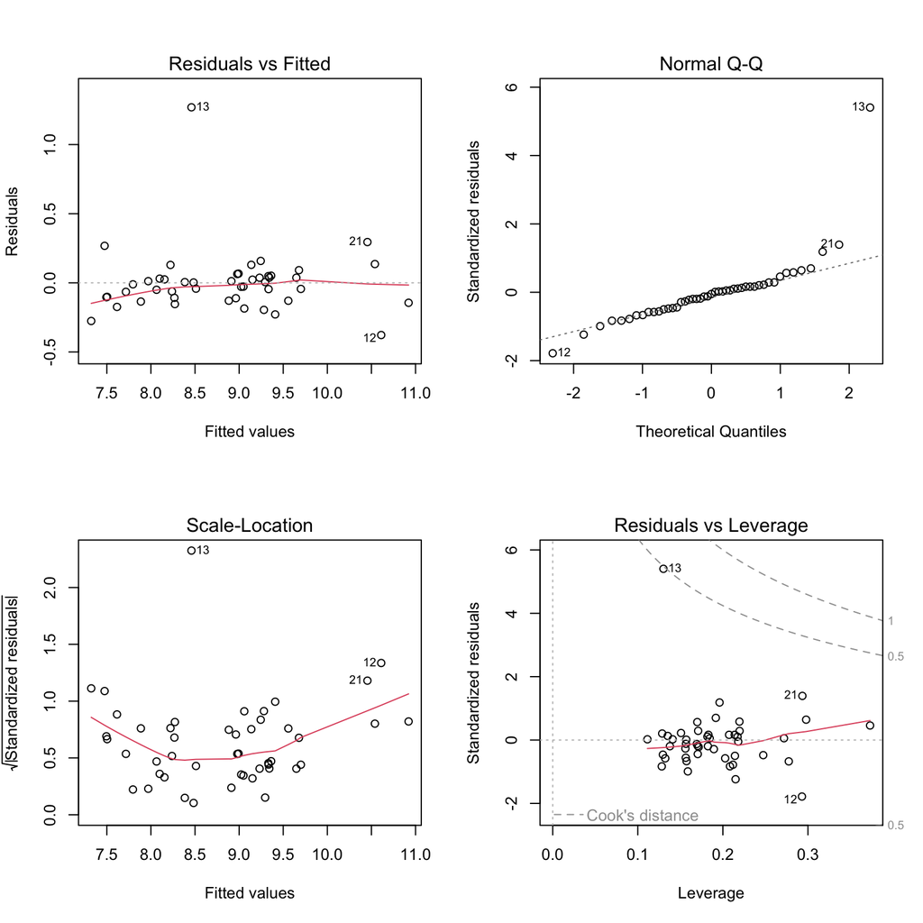

```r
par(mfrow=c(2,2))
plot(model_3lnBMI)
```

## Question 5

Use the 3 withheld observations and calculate the performance measures for your best two models. Which is the better model? (remember that “better” depends on whether your outlook is short or long run)

```r
test$lnCharges <- log(test$Charges)
test$lnAge <- log(test$Age)
test$AgeSquared <- test$Age^2
test$lnBMI <- log(test$BMI)

test$original_model_pred <- predict(original_model, newdata = test)

test$model_1lnAge_pred <- predict(model_1lnAge,newdata = test) %>% exp()

test$model_2AgeSq_pred <- predict(model_2AgeSq,newdata = test) %>% exp()

test$model_3lnBMI_pred <- predict(model_3lnBMI,newdata = test) %>% exp()
```

```r
# Finding the error

test$error_OM <- test$original_model_pred - test$Charges

test$error_1lnAge<- test$model_1lnAge_pred - test$Charges

test$error_2SqAge<- test$model_2AgeSq_pred - test$Charges

test$error_3lnBMI<- test$model_3lnBMI_pred - test$Charges
```

```r
# Bias

# Original Model
mean(test$error_OM)
```

```
## [1] 4879.738
```

```r
# Model 1lnAge
mean(test$error_1lnAge)
```

```
## [1] 2656.491
```

```r
# Model 2SqAge
mean(test$error_2SqAge)
```

```
## [1] 7168.83
```

```r
#Model 3lnBMI
mean(test$error_3lnBMI)
```

```
## [1] 2627.923
```

BIAS [1] 4879.738 [1] 2656.491 [1] 7168.83 [1] 2627.923 (best)

```r
# MAE

mae <- function(error_vector){
  error_vector %>%
  abs() %>%
  mean()}

# Original Model
mae(test$error_OM)
```

```
## [1] 5721.517
```

```r
# Model 1lnAge
mae(test$error_1lnAge)
```

```
## [1] 9328.276
```

```r
# Model 2SqAge
mae(test$error_2Sq)
```

```
## [1] 12033.55
```

```r
#Model 3lnBMI
mae(test$error_3lnBMI)
```

```
## [1] 9300.512
```

MAE [1] 5721.517 [1] 9328.276 [1] 12033.55 [1] 9300.512 better

```r
### RMSE
rmse <- function(error_vector){
   error_vector^2 %>%
  mean() %>%
  sqrt()}

# Original Model
rmse(test$error_OM)
```

```
## [1] 6627.591
```

```r
# Model 1lnAge
rmse(test$error_1lnAge)
```

```
## [1] 11853.78
```

```r
# Model 2SqAge
rmse(test$error_2SqAge)
```

```
## [1] 17117.81
```

```r
#Model 3lnBMI
rmse(test$error_3lnBMI)
```

```
## [1] 11808.4
```

```r
### MAPE
mape <- function(error_vector, actual_vector){
  (error_vector/actual_vector) %>%
    abs() %>%
    mean()
}

# Original Model
mape(test$error_OM, test$Charges)
```

```
## [1] 0.3584357
```

```r
# Model 1lnAge
mape(test$error_1lnAge, test$Charges)
```

```
## [1] 0.406728
```

```r
# Model 2SqAge
mape(test$error_2SqAge, test$Charges)
```

```
## [1] 0.4912408
```

```r
# Model 3lnBMI
mape(test$error_3lnBMI, test$Charges)
```

```
## [1] 0.4066504
```

# Question 5 Answer

Summary of Performance Metrics BIAS [1] 4879.738 [1] 2656.491 lower bias better for long run [1] 7168.83 [1] 2627.923 (best) over prediction MAE [1] 5721.517 [1] 9328.276 [1] 12033.55 [1] 9300.512 better RMSE [1] 6627.591 [1] 11853.78 [1] 17117.81 [1] 11808.4 better MAPE [1] 0.3584357 [1] 0.406728 [1] 0.4912408 [1] 0.4066504 better

## Question 6

Provide interpretations of the coefficients, do the signs make sense? Perform marginal change analysis (thing 2) on the independent variables.

```r
### Marginal Change Analysis

model_3lnBMI$coefficients["lnAge"]
```

```
##   lnAge
## 1.53895
```

```r
model_3lnBMI$coefficients["Female"]
```

```
##    Female
## 0.1360697
```

```r
model_3lnBMI$coefficients["Children"]
```

```
##   Children
## 0.07963402
```

```r
model_3lnBMI$coefficients["Smoker"]
```

```
##   Smoker
## 1.255853
```

```r
model_3lnBMI$coefficients["WinterSprings"]
```

```
## WinterSprings
##     0.1992206
```

# Question 6 Answer==>

Marginal Change Analysis lnAge 1.53895 Female 0.1360697 Children 0.07963402 Smoker 1.255853 WinterSprings 0.1992206